# Customer Churn Modeling in R

Rodrigo Gasha

August 28th, 2021

# Introduction

Customer Churn refers to the rate of customer attrition in a company or in simpler words speed at which customer leaves your company or service.

A predictive Churn Model is a straightforward classification tool: look at the user activity from the past and check to see who is active after a certain time and then create a model that probabilistically identifies the steps and stages when a customer (or segment) is leaving your service or product.

Having a predictive churn model gives you awareness and quantifiable metrics to fight against in your retention efforts. This gives you the ability to pattern habits of customers who leave, and step in before they make that decision. Without this tool, you would be acting on broad assumptions, not a data-driven model that reflects how your customers really act.

The dataset can be found at the following link: https://www.kaggle.com/shubh0799/churn-modelling. It contains details of costumers in a company. The objective of this document is to evaluate the performance of four classification models:

1. Logistic Regression
2. k-Nearest Neighbors
3. Random Forest
4. Support Vector Machine

## Set Up and Data Wrangling

```r
# Install packages
pacman::p_load(pacman, ggplot2, tidyverse, randomForest, GGally, caret,
               e1071, dplyr, tidyr, caret, reshape2, RColorBrewer, ggthemes,
               kernlab, magrittr, knitr, mlr, ROSE, MLmetrics)
```

```r
# Dataset import
data <- read.csv("Churn_Modelling.csv")
str(data)
```

```
## 'data.frame':    10000 obs. of  14 variables:
##  $ RowNumber      : int  1 2 3 4 5 6 7 8 9 10 ...
##  $ CustomerId     : int  15634602 15647311 15619304 15701354 15737888 15574012 15592531 15656148 15792365 15592389 ...
##  $ Surname        : chr  "Hargrave" "Hill" "Onio" "Boni" ...
##  $ CreditScore    : int  619 608 502 699 850 645 822 376 501 684 ...
##  $ Geography      : chr  "France" "Spain" "France" "France" ...
##  $ Gender         : chr  "Female" "Female" "Female" "Female" ...
##  $ Age            : int  42 41 42 39 43 44 50 29 44 27 ...
##  $ Tenure         : int  2 1 8 1 2 8 7 4 4 2 ...
##  $ Balance        : num  0 83808 159661 0 125511 ...
##  $ NumOfProducts  : int  1 1 3 2 1 2 2 4 2 1 ...
##  $ HasCrCard      : int  1 0 1 0 1 1 1 1 0 1 ...
##  $ IsActiveMember : int  1 1 0 0 1 0 1 0 1 1 ...
##  $ EstimatedSalary: num  101349 112543 113932 93827 79084 ...
##  $ Exited         : int  1 0 1 0 0 1 0 1 0 0 ...
```

```r
# Remove unnecessary columns
data <- data[,-(1:3)]
```

## Exploratory Data Analysis

```r
# Pie chart de exited
summary(data)
```

```
##   CreditScore     Geography            Gender               Age
##  Min.   :350.0   Length:10000       Length:10000       Min.   :18.00
##  1st Qu.:584.0   Class :character   Class :character   1st Qu.:32.00
##  Median :652.0   Mode  :character   Mode  :character   Median :37.00
##  Mean   :650.5                                         Mean   :38.92
##  3rd Qu.:718.0                                         3rd Qu.:44.00
##  Max.   :850.0                                         Max.   :92.00
##      Tenure          Balance       NumOfProducts    HasCrCard
##  Min.   : 0.000   Min.   :     0   Min.   :1.00   Min.   :0.0000
##  1st Qu.: 3.000   1st Qu.:     0   1st Qu.:1.00   1st Qu.:0.0000
##  Median : 5.000   Median : 97199   Median :1.00   Median :1.0000
##  Mean   : 5.013   Mean   : 76486   Mean   :1.53   Mean   :0.7055
##  3rd Qu.: 7.000   3rd Qu.:127644   3rd Qu.:2.00   3rd Qu.:1.0000
##  Max.   :10.000   Max.   :250898   Max.   :4.00   Max.   :1.0000
##  IsActiveMember   EstimatedSalary         Exited
##  Min.   :0.0000   Min.   :    11.58   Min.   :0.0000
##  1st Qu.:0.0000   1st Qu.: 51002.11   1st Qu.:0.0000
##  Median :1.0000   Median :100193.91   Median :0.0000
##  Mean   :0.5151   Mean   :100090.24   Mean   :0.2037
##  3rd Qu.:1.0000   3rd Qu.:149388.25   3rd Qu.:0.0000
##  Max.   :1.0000   Max.   :199992.48   Max.   :1.0000
```

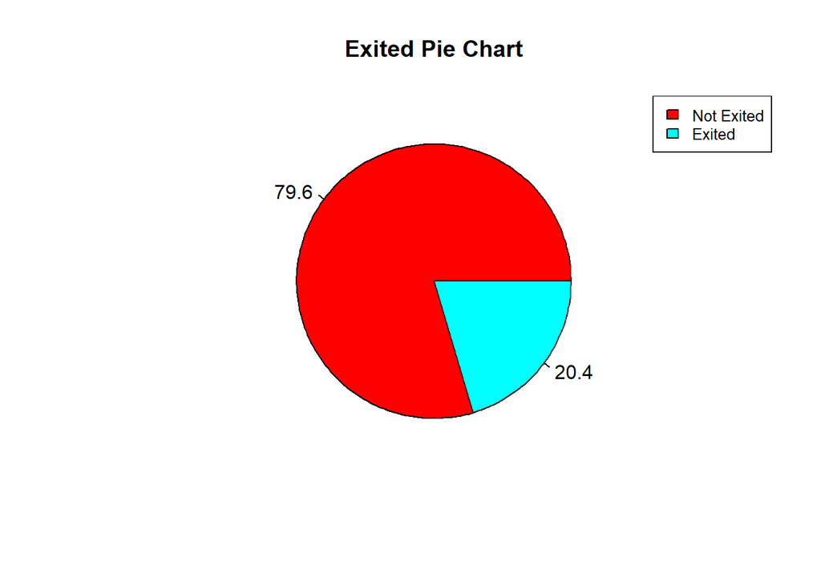

```r
perc <- as.vector(table(data$Exited))
piepercent <- round(100*perc/sum(perc), 1)
pie(perc, labels = piepercent, main = "Exited Pie Chart",col = rainbow(length(perc)))
legend("topright", c("Not Exited", "Exited"), cex = 0.8,
       fill = rainbow(length(perc)))
```

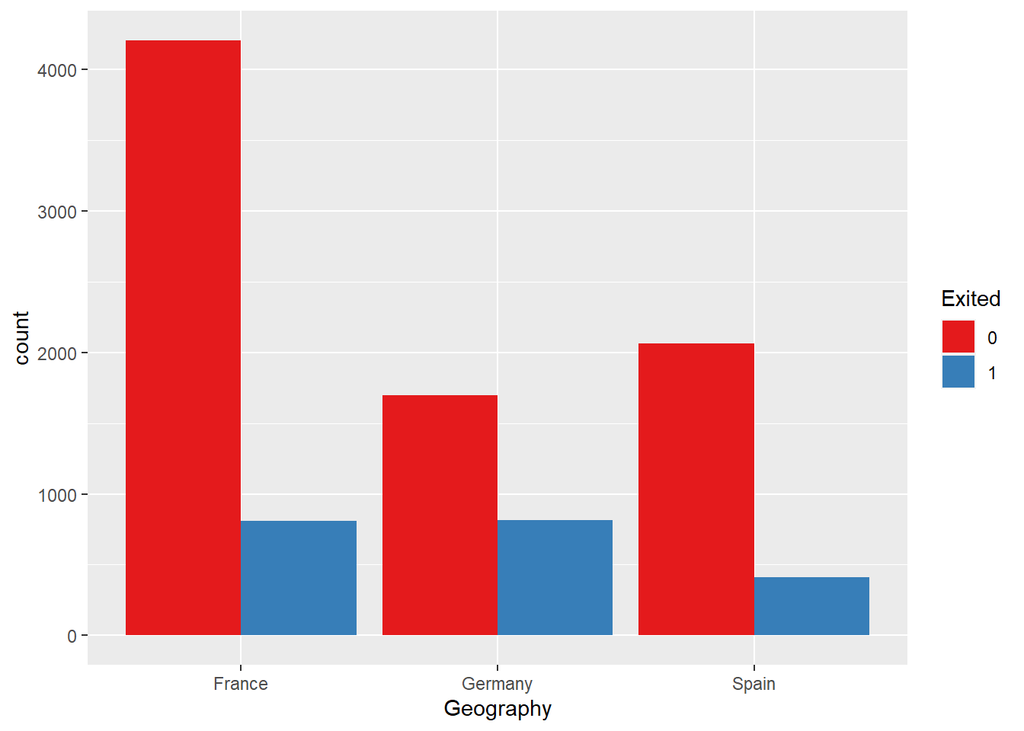

```r
# Histograms
data %>%
  ggplot(aes(x = Geography, fill = factor(Exited))) +
  geom_bar(position = "dodge") +
  scale_fill_brewer(palette = "Set1") +
  labs(x = "Geography") +
  guides(fill=guide_legend(title="Exited"))
```

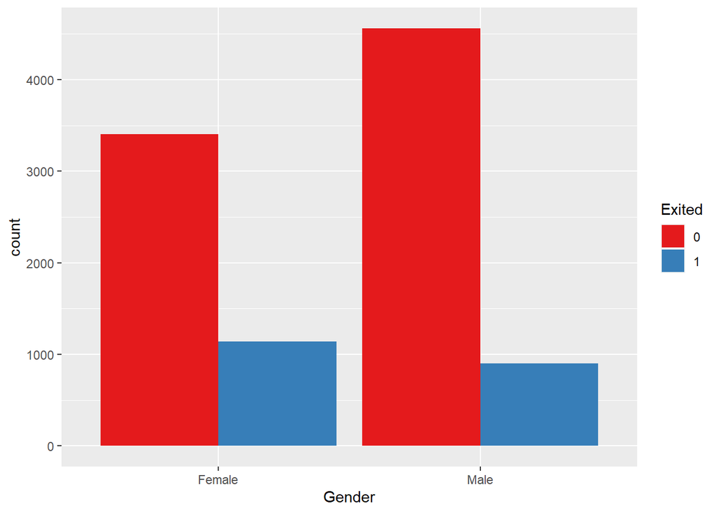

```r
data %>%
  ggplot(aes(x = Gender, fill = factor(Exited))) +
  geom_bar(position = "dodge") +
  scale_fill_brewer(palette = "Set1") +
  labs(x = "Gender") +
  guides(fill=guide_legend(title="Exited"))
```

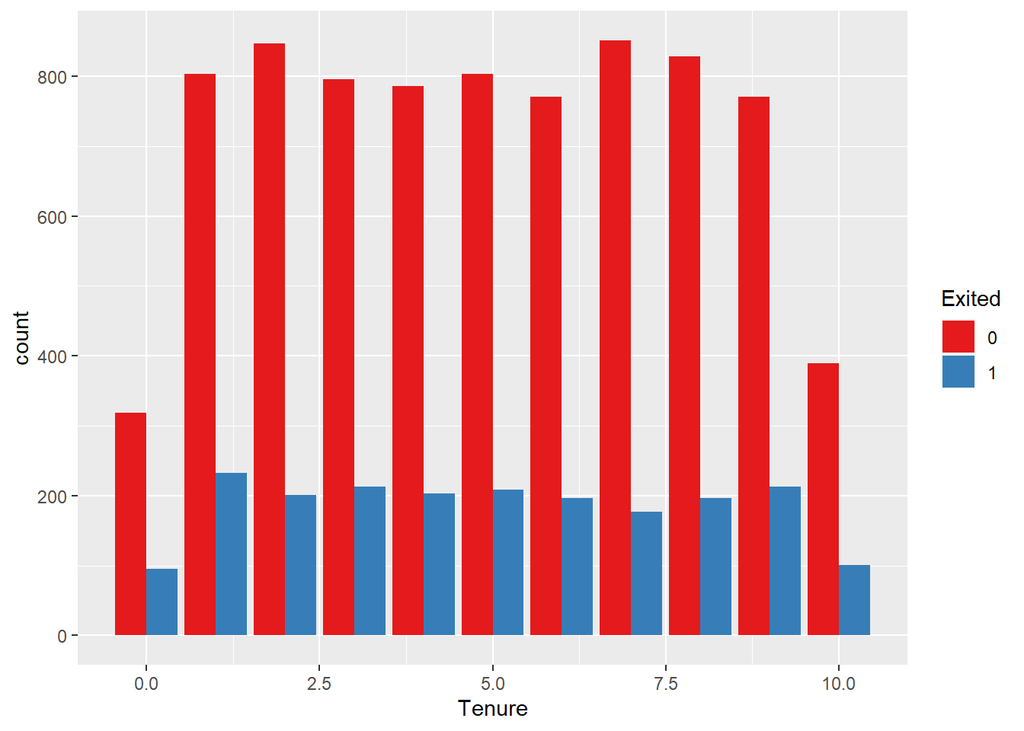

```r
data %>%
  ggplot(aes(x = Tenure, fill = factor(Exited))) +
  geom_bar(position = "dodge") +
  scale_fill_brewer(palette = "Set1") +
  labs(x = "Tenure") +
  guides(fill=guide_legend(title="Exited"))
```

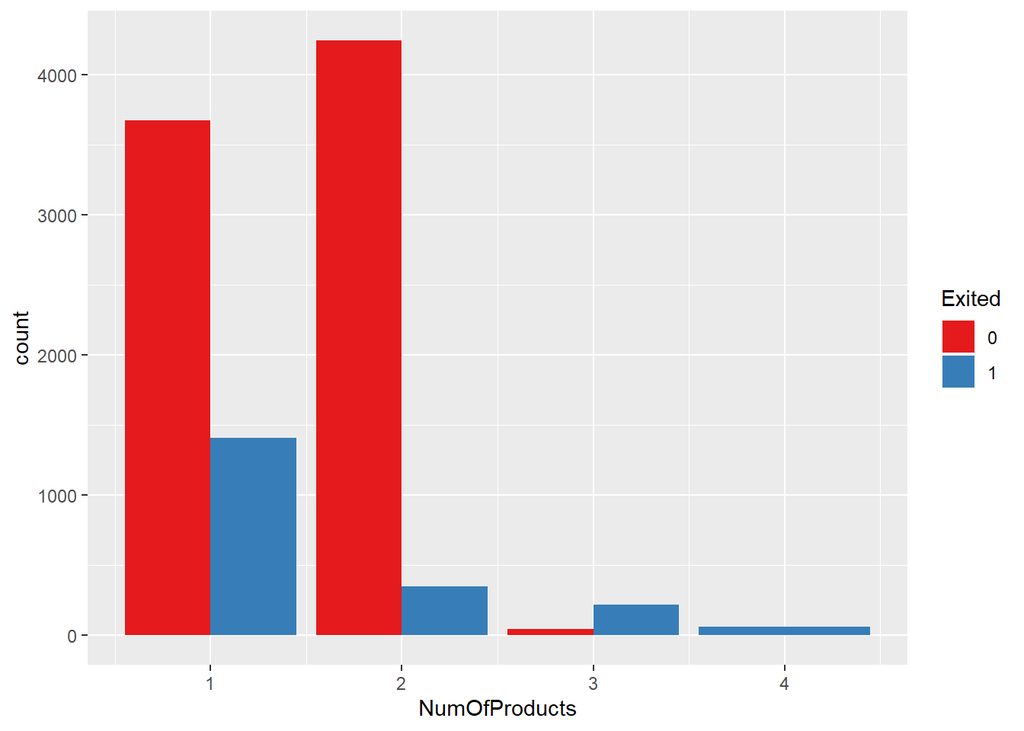

```r
data %>%
  ggplot(aes(x = NumOfProducts, fill = factor(Exited))) +
  geom_bar(position = "dodge") +
  scale_fill_brewer(palette = "Set1") +
  labs(x = "NumOfProducts") +
  guides(fill=guide_legend(title="Exited"))
```

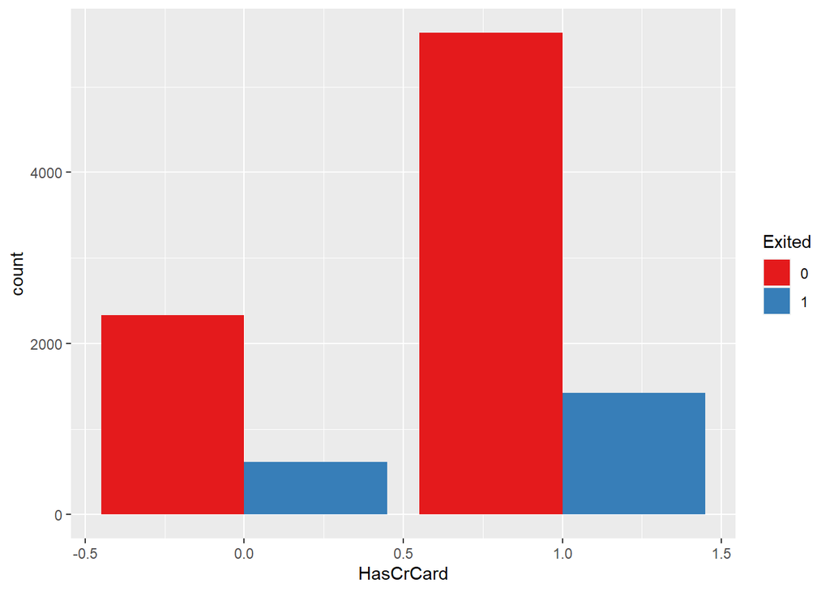

```r
data %>%
  ggplot(aes(x = HasCrCard, fill = factor(Exited))) +
  geom_bar(position = "dodge") +
  scale_fill_brewer(palette = "Set1") +
  labs(x = "HasCrCard") +
  guides(fill=guide_legend(title="Exited"))
```

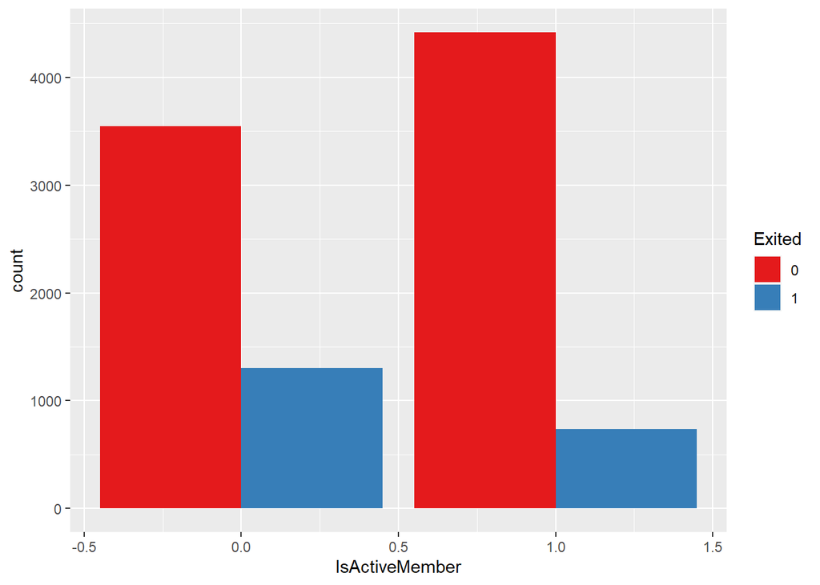

```r
data %>%
  ggplot(aes(x = IsActiveMember, fill = factor(Exited))) +
  geom_bar(position = "dodge") +
  scale_fill_brewer(palette = "Set1") +
  labs(x = "IsActiveMember") +
  guides(fill=guide_legend(title="Exited"))
```

From the charts above we can conclude:

- The majority of clients are French but most of the churned costumers come from Germany, in proportion to the total per country of origin
- The proportion of female customers churning is greater than that of male customers
- Most of the costumers have a tenure between 1 and 9 whether they churned or not
- The majority of costumers have up to 2 products. However, most of the churned clients have only 1 product
- Most of churned clients possess a credit card but also most of the customers have one
- As expected, the majority of churned clients are inactive members

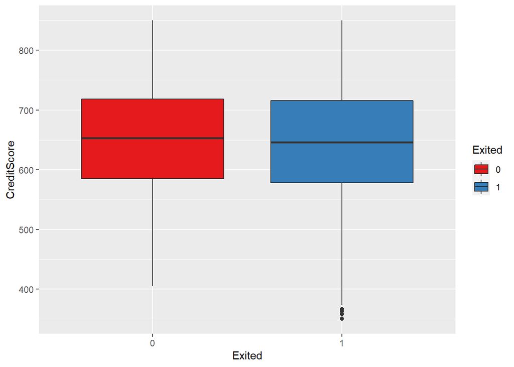

```r
# Box Plots
data %>%
  ggplot(aes(x = factor(Exited), y = CreditScore, fill= factor(Exited))) +
  geom_boxplot() +
  labs(x = "Exited") +
  scale_fill_brewer(palette="Set1") +
  guides(fill=guide_legend(title="Exited"))
```

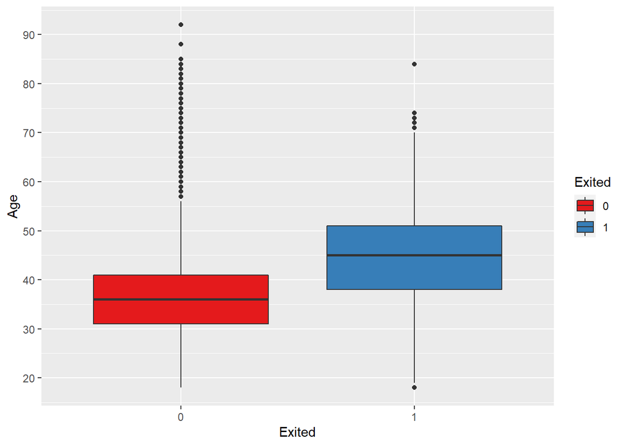

```r
data %>%
  ggplot(aes(x = factor(Exited), y = Age, fill=factor(Exited))) +
  geom_boxplot() +
  labs(x = "Exited") +
  scale_y_continuous(breaks=seq(0,100,10)) +
  scale_fill_brewer(palette="Set1") +
  guides(fill=guide_legend(title="Exited"))
```

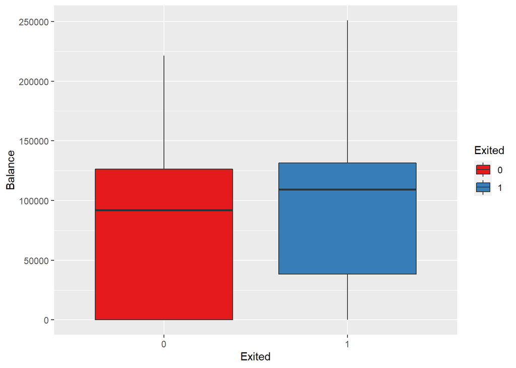

```r
data %>%
  ggplot(aes(x = factor(Exited), y = Balance, fill=factor(Exited))) +
  geom_boxplot() +
  labs(x = "Exited")+
  scale_fill_brewer(palette="Set1") +
  guides(fill=guide_legend(title="Exited"))
```

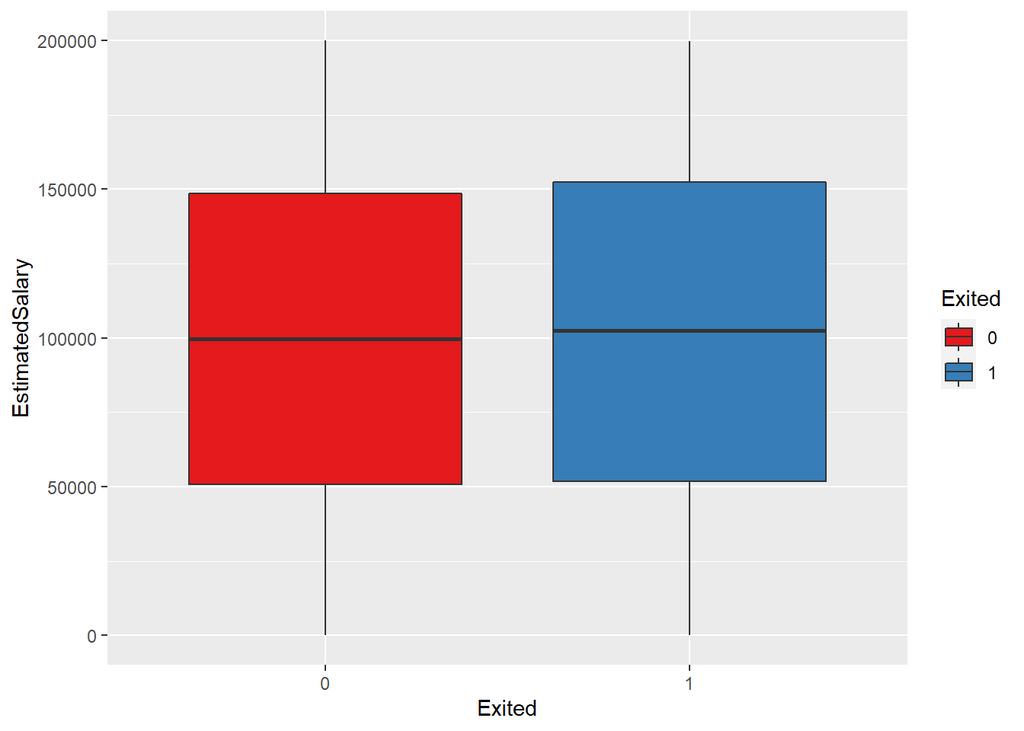

```r
data %>%
  ggplot(aes(x = factor(Exited), y = EstimatedSalary, fill=factor(Exited))) +
  geom_boxplot() +
  labs(x = "Exited")+
  scale_fill_brewer(palette="Set1") +
  guides(fill=guide_legend(title="Exited"))
```

From the above plots we conclude that:

- There is no significant difference in credit score distribution between churned a not churned clients
- Older customers are churning more than younger ones
- Clients with significant balance are prone to churn more
- Estimated Salary does not have a significant impact on the likelihood to churn

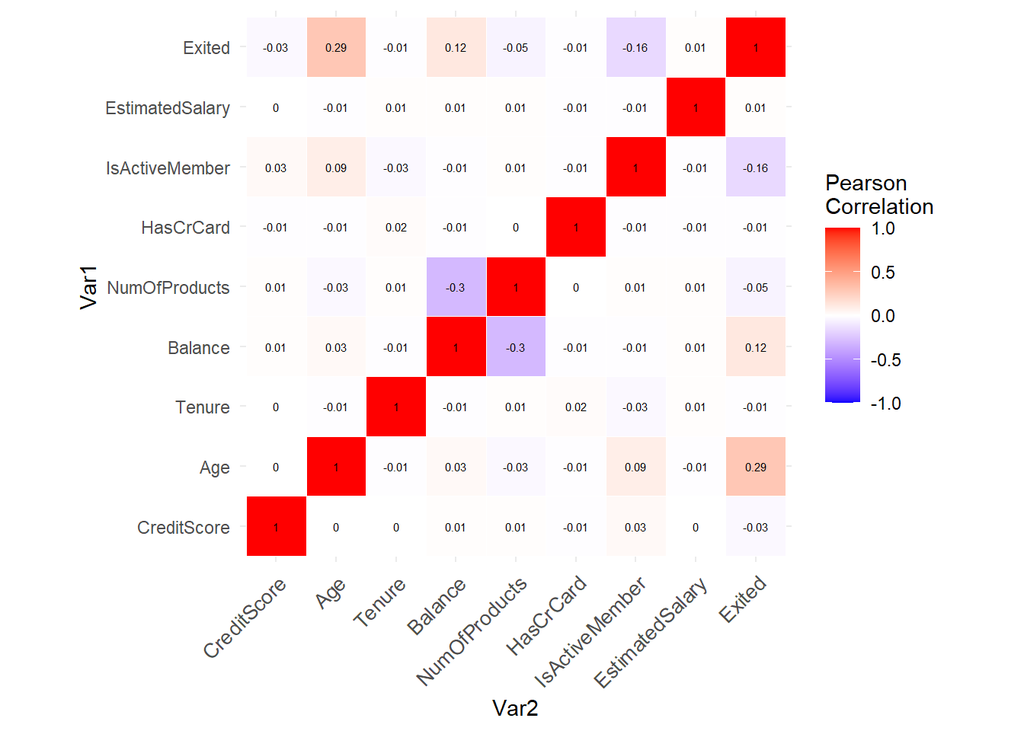

```r
# Correlation Heatmap
cormat <- round(cor(data[,(-2:-3)]),2)
melted_cormat <- melt(cormat)
ggplot(data = melted_cormat, aes(Var2, Var1, fill = value))+
  geom_tile(color = "white")+
  scale_fill_gradient2(low = "blue", high = "red", mid = "white",
                       midpoint = 0, limit = c(-1,1), space = "Lab",
                       name="Pearson\nCorrelation") +
  theme_minimal()+
  theme(axis.text.x = element_text(angle = 45, vjust = 1,
                                   size = 10, hjust = 1))+
  coord_fixed()+
  geom_text(aes(Var2, Var1, label = value), color = "black", size = 2)
```

There is no multicollinearity present in data.

## Data Preprocessing and Splitting Data

```r
# Categorical Columns as Factor
data$Exited[data$Exited == 0] <- 'No'
data$Exited[data$Exited == 1] <- 'Yes'
categcol <- c("Geography", "Gender", "HasCrCard","IsActiveMember", "Exited")
data[categcol] <- lapply(data[categcol], factor)

# Feature Scaling
data <- rapply(data,scale,c("numeric","integer"),how="replace")
```

```r
# Data Partition - Train and Test
set.seed(1)
ind <- sample(2, nrow(data), replace = TRUE, prob = c(0.8, 0.2))
train <- data[ind==1,]
test <- data[ind==2,]
```

```r
# Oversampling Imbalanced Data
set.seed(1)
table(train$Exited)
```

```
##
##   No  Yes
## 6320 1612
```

```r
n <- length(which(train$Exited == "No"))
train <- ovun.sample(Exited ~ ., data=train, method="over", N=n*2)$data

# Train proportion after oversampling
table(train$Exited)
```

```
##
##   No  Yes
## 6320 6320
```

# Classification Model

## Logistic Regression

```r
lr <- glm(Exited ~ ., data=train, family='binomial')
summary(lr)
```

```
##
## Call:
## glm(formula = Exited ~ ., family = "binomial", data = train)
##
## Deviance Residuals:
##      Min        1Q    Median        3Q       Max
## -2.90666  -0.94154  -0.03498   0.94447   2.55637
##
## Coefficients:
##                   Estimate Std. Error z value Pr(>|z|)
## (Intercept)       0.283444   0.050516   5.611 2.01e-08 ***
## CreditScore      -0.066009   0.020005  -3.300 0.000968 ***
## GeographyGermany  0.760279   0.051283  14.825  < 2e-16 ***
## GeographySpain    0.071430   0.050752   1.407 0.159299
## GenderMale       -0.576640   0.040485 -14.243  < 2e-16 ***
## Age               0.846184   0.022509  37.594  < 2e-16 ***
## Tenure           -0.030644   0.020182  -1.518 0.128924
## Balance           0.157618   0.022811   6.910 4.85e-12 ***
## NumOfProducts    -0.071559   0.017672  -4.049 5.14e-05 ***
## HasCrCard1       -0.003659   0.043962  -0.083 0.933675
## IsActiveMember1  -0.941028   0.041071 -22.912  < 2e-16 ***
## EstimatedSalary   0.019035   0.020082   0.948 0.343204
## ---
## Signif. codes:  0 '***' 0.001 '**' 0.01 '*' 0.05 '.' 0.1 ' ' 1
##
## (Dispersion parameter for binomial family taken to be 1)
##
##     Null deviance: 17523  on 12639  degrees of freedom
## Residual deviance: 14495  on 12628  degrees of freedom
## AIC: 14519
##
## Number of Fisher Scoring iterations: 4
```

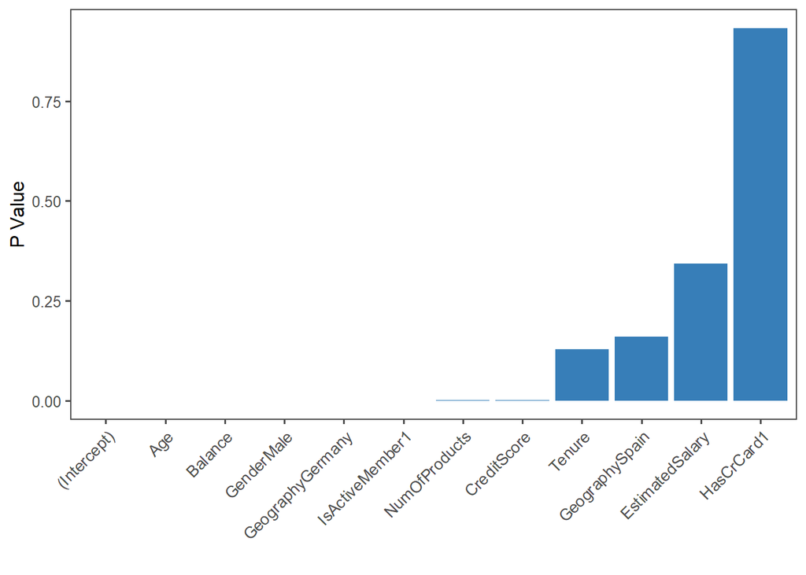

```r
lr %>%
  summary() %>%
  coef() %>%
  as_tibble() %>%
  cbind(Variable = lr %>%
          summary() %>%
          coef() %>% rownames(),.) %>%
  mutate(`Pr(>|z|)` = round(`Pr(>|z|)`, 6)) %>%
  ggplot(aes(x = reorder(Variable, `Pr(>|z|)`), y = `Pr(>|z|)`)) +
  geom_bar(stat = "identity", fill = brewer.pal(n = 5, "Set1")[2]) +
  labs(x = "",
       y = "P Value") +
  theme_few() +
  theme(axis.text.x = element_text(angle = 45,
                                   size = 10,
                                   vjust = 1,
                                   hjust = 1))
```

```r
# Significance testing of categorical features
lr1 <- glm(Exited ~ . - Geography, data=train, family='binomial')
anova(lr, lr1, test="LRT")
```

```
## Analysis of Deviance Table
##
## Model 1: Exited ~ CreditScore + Geography + Gender + Age + Tenure + Balance +
##     NumOfProducts + HasCrCard + IsActiveMember + EstimatedSalary
## Model 2: Exited ~ (CreditScore + Geography + Gender + Age + Tenure + Balance +
##     NumOfProducts + HasCrCard + IsActiveMember + EstimatedSalary) -
##     Geography
##   Resid. Df Resid. Dev Df Deviance  Pr(>Chi)
## 1     12628      14495
## 2     12630      14733 -2  -238.06 < 2.2e-16 ***
## ---
## Signif. codes:  0 '***' 0.001 '**' 0.01 '*' 0.05 '.' 0.1 ' ' 1
```

```r
lr2 <- glm(Exited ~ . - Gender, data=train, family='binomial')
anova(lr, lr2, test="LRT")
```

```
## Analysis of Deviance Table
##
## Model 1: Exited ~ CreditScore + Geography + Gender + Age + Tenure + Balance +
##     NumOfProducts + HasCrCard + IsActiveMember + EstimatedSalary
## Model 2: Exited ~ (CreditScore + Geography + Gender + Age + Tenure + Balance +
##     NumOfProducts + HasCrCard + IsActiveMember + EstimatedSalary) -
##     Gender
##   Resid. Df Resid. Dev Df Deviance  Pr(>Chi)
## 1     12628      14495
## 2     12629      14701 -1  -205.31 < 2.2e-16 ***
## ---
## Signif. codes:  0 '***' 0.001 '**' 0.01 '*' 0.05 '.' 0.1 ' ' 1
```

```r
lr3 <- glm(Exited ~ . - HasCrCard, data=train, family='binomial')
anova(lr, lr3, test="LRT")
```

```
## Analysis of Deviance Table
##
## Model 1: Exited ~ CreditScore + Geography + Gender + Age + Tenure + Balance +
##     NumOfProducts + HasCrCard + IsActiveMember + EstimatedSalary
## Model 2: Exited ~ (CreditScore + Geography + Gender + Age + Tenure + Balance +
##     NumOfProducts + HasCrCard + IsActiveMember + EstimatedSalary) -
##     HasCrCard
##   Resid. Df Resid. Dev Df   Deviance Pr(>Chi)
## 1     12628      14495
## 2     12629      14495 -1 -0.0069259   0.9337
```

```r
lr4 <- glm(Exited ~ . - IsActiveMember, data=train, family='binomial')
anova(lr, lr4, test="LRT")
```

```
## Analysis of Deviance Table
##
## Model 1: Exited ~ CreditScore + Geography + Gender + Age + Tenure + Balance +
##     NumOfProducts + HasCrCard + IsActiveMember + EstimatedSalary
## Model 2: Exited ~ (CreditScore + Geography + Gender + Age + Tenure + Balance +
##     NumOfProducts + HasCrCard + IsActiveMember + EstimatedSalary) -
##     IsActiveMember
##   Resid. Df Resid. Dev Df Deviance  Pr(>Chi)
## 1     12628      14495
## 2     12629      15040 -1  -545.03 < 2.2e-16 ***
## ---
## Signif. codes:  0 '***' 0.001 '**' 0.01 '*' 0.05 '.' 0.1 ' ' 1
```

```r
# Model fit
lr5 <- glm(Exited ~ . -HasCrCard - EstimatedSalary - Tenure, data=train, family='binomial')
summary(lr5)
```

```
##
## Call:
## glm(formula = Exited ~ . - HasCrCard - EstimatedSalary - Tenure,
##     family = "binomial", data = train)
##
## Deviance Residuals:
##      Min        1Q    Median        3Q       Max
## -2.91746  -0.94265  -0.03703   0.94588   2.54299
##
## Coefficients:
##                  Estimate Std. Error z value Pr(>|z|)
## (Intercept)       0.28164    0.03976   7.084 1.40e-12 ***
## CreditScore      -0.06700    0.01999  -3.352 0.000803 ***
## GeographyGermany  0.75835    0.05125  14.798  < 2e-16 ***
## GeographySpain    0.07292    0.05072   1.438 0.150503
## GenderMale       -0.57896    0.04046 -14.309  < 2e-16 ***
## Age               0.84669    0.02250  37.631  < 2e-16 ***
## Balance           0.15788    0.02280   6.925 4.36e-12 ***
## NumOfProducts    -0.07170    0.01766  -4.060 4.90e-05 ***
## IsActiveMember1  -0.93911    0.04101 -22.902  < 2e-16 ***
## ---
## Signif. codes:  0 '***' 0.001 '**' 0.01 '*' 0.05 '.' 0.1 ' ' 1
##
## (Dispersion parameter for binomial family taken to be 1)
##
##     Null deviance: 17523  on 12639  degrees of freedom
## Residual deviance: 14498  on 12631  degrees of freedom
## AIC: 14516
##
## Number of Fisher Scoring iterations: 4
```

```r
# Prediction
p1 <- predict(lr5, newdata = test, type = "response")

# Grid search of "p" threshold
grid <- expand.grid(p= seq(0.05,0.95,by=0.05))

# Add columns to store results
grid %<>% mutate(F1_Score = rep(0,nrow(grid)))

# Fit model
for (i in 1:nrow(grid)) {

  p = grid[i,1]
  f1 <- F1_Score(y_pred = as.factor(ifelse(p1>p, "Yes", "No")), y_true = test$Exited,
                 positive= "Yes")
  grid[i,2] = f1

  rm(f1, p)
}

# Grid
grid
```

```
##       p   F1_Score
## 1  0.05 0.34150261
## 2  0.10 0.34811166
## 3  0.15 0.36332030
## 4  0.20 0.38126160
## 5  0.25 0.40403023
## 6  0.30 0.43237251
## 7  0.35 0.45070423
## 8  0.40 0.47664835
## 9  0.45 0.48929664
## 10 0.50 0.50256410
## 11 0.55 0.50528338
## 12 0.60 0.49513514
## 13 0.65 0.47272727
## 14 0.70 0.43126685
## 15 0.75 0.37405732
## 16 0.80 0.29655172
## 17 0.85 0.21832359
## 18 0.90 0.07488987
## 19 0.95 0.01392111
```

With p=0.55 the model reaches the highest F1 Score.

```r
# Final Model
p=0.55
cm1 <- confusionMatrix(data = as.factor(ifelse(p1>p, "Yes", "No")), reference = test$Exited, positive="Yes")
cm1
```

```
## Confusion Matrix and Statistics
##
##           Reference
## Prediction   No  Yes
##        No  1290  162
##        Yes  353  263
##
##                Accuracy : 0.751
##                  95% CI : (0.7317, 0.7695)
##     No Information Rate : 0.7945
##     P-Value [Acc > NIR] : 1
##
##                   Kappa : 0.3463
##
##  Mcnemar's Test P-Value : <2e-16
##
##             Sensitivity : 0.6188
##             Specificity : 0.7851
##          Pos Pred Value : 0.4269
##          Neg Pred Value : 0.8884
##              Prevalence : 0.2055
##          Detection Rate : 0.1272
##    Detection Prevalence : 0.2979
##       Balanced Accuracy : 0.7020
##
##        'Positive' Class : Yes
##
```

```r
F1_1 <- F1_Score(y_pred = as.factor(ifelse(p1>p, "Yes", "No")), y_true = test$Exited, positive= "Yes")
F1_1
```

```
## [1] 0.5052834
```

## KNN

```r
set.seed(1)

# Tune k parameter
f1 <- function (data, lev = NULL, model = NULL) {
  precision <- posPredValue(data$pred, data$obs, positive = "Yes")
  recall  <- sensitivity(data$pred, data$obs, postive = "Yes")
  f1_val <- (2 * precision * recall) / (precision + recall)
  names(f1_val) <- c("F1")
  f1_val
}

KNN <- caret::train(Exited ~ ., data = train,
             method= 'knn',
             tuneLength = 20,
             metric = "F1",
             trControl = trainControl(method = "repeatedcv",
                                      number=10,
                                      repeats=3,
                                      summaryFunction = f1,
                                      search = "grid"))
# Model Performance
KNN
```

```
## k-Nearest Neighbors
##
## 12640 samples
##    10 predictor
##     2 classes: 'No', 'Yes'
##
## No pre-processing
## Resampling: Cross-Validated (10 fold, repeated 3 times)
## Summary of sample sizes: 11376, 11376, 11376, 11376, 11376, 11376, ...
## Resampling results across tuning parameters:
##
##   k   F1
##    5  0.7328422
##    7  0.7378180
##    9  0.7424234
##   11  0.7490850
##   13  0.7526985
##   15  0.7523379
##   17  0.7550562
##   19  0.7574157
##   21  0.7604762
##   23  0.7620372
##   25  0.7617502
##   27  0.7604340
##   29  0.7627110
##   31  0.7642160
##   33  0.7663508
##   35  0.7676404
##   37  0.7679315
##   39  0.7678111
##   41  0.7674063
##   43  0.7673669
##
## F1 was used to select the optimal model using the largest value.
## The final value used for the model was k = 37.
```

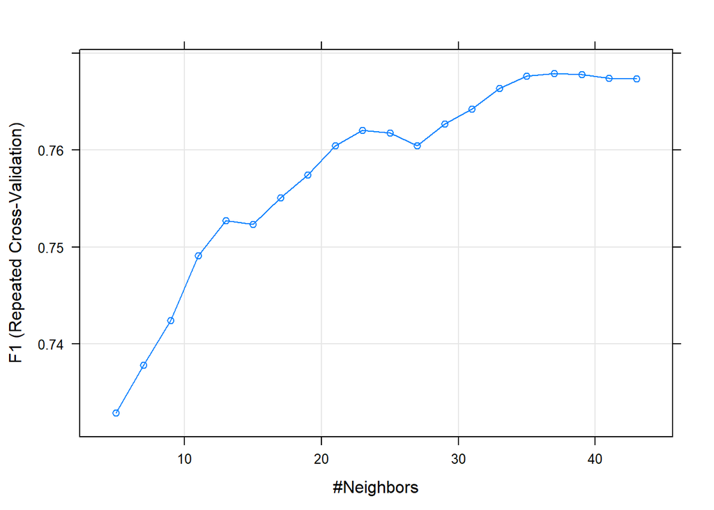

```r
plot(KNN)
```

K = 37 has the highest F1 Score.

```r
# Variables importance
varImp(KNN)
```

```
## ROC curve variable importance
##
##                 Importance
## Age                100.000
## IsActiveMember      40.244
## NumOfProducts       34.657
## Balance             31.100
## Gender              28.271
## Geography           16.104
## CreditScore          6.994
## Tenure               2.777
## EstimatedSalary      2.432
## HasCrCard            0.000
```

```r
plot(varImp(KNN))
```

[output not shown]

```r
# Final Model
set.seed(1)
p2 <- predict(KNN, newdata = test)
cm2 <- confusionMatrix(p2, test$Exited, positive = "Yes")
cm2
```

```
## Confusion Matrix and Statistics
##
##           Reference
## Prediction   No  Yes
##        No  1289  116
##        Yes  354  309
##
##                Accuracy : 0.7727
##                  95% CI : (0.754, 0.7906)
##     No Information Rate : 0.7945
##     P-Value [Acc > NIR] : 0.9929
##
##                   Kappa : 0.4237
##
##  Mcnemar's Test P-Value : <2e-16
##
##             Sensitivity : 0.7271
##             Specificity : 0.7845
##          Pos Pred Value : 0.4661
##          Neg Pred Value : 0.9174
##              Prevalence : 0.2055
##          Detection Rate : 0.1494
##    Detection Prevalence : 0.3206
##       Balanced Accuracy : 0.7558
##
##        'Positive' Class : Yes
##
```

```r
F1_2 <- F1_Score(y_pred = p2, y_true = test$Exited, positive = "Yes")
F1_2
```

```
## [1] 0.5680147
```

## Random Forest

```r
# Tune mtry Parameter
set.seed(1)
tune.grid <- expand.grid(.mtry = seq(from = 1, to = 10, by = 1))
rf<- caret::train(Exited ~ .,
                 data = train,
                 method = "rf",
                 tuneGrid = tune.grid,
                 metric = "F1",
                 trControl = trainControl(method = "cv",
                          number = 10,
                          classProbs = TRUE,
                          summaryFunction = f1,
                          search = "grid"))

rf
```

```
## Random Forest
##
## 12640 samples
##    10 predictor
##     2 classes: 'No', 'Yes'
##
## No pre-processing
## Resampling: Cross-Validated (10 fold)
## Summary of sample sizes: 11376, 11376, 11376, 11376, 11376, 11376, ...
## Resampling results across tuning parameters:
##
##   mtry  F1
##    1    0.8148512
##    2    0.8830489
##    3    0.9196508
##    4    0.9289733
##    5    0.9282181
##    6    0.9263038
##    7    0.9251148
##    8    0.9221780
##    9    0.9217180
##   10    0.9190632
##
## F1 was used to select the optimal model using the largest value.
## The final value used for the model was mtry = 4.
```

mtry = 4 has the highest F1 Score.

```r
# Final Model
set.seed(1)
p3 <- predict(rf, test)
cm3 <- confusionMatrix(p3, test$Exited, positive = "Yes")
cm3
```

```
## Confusion Matrix and Statistics
##
##           Reference
## Prediction   No  Yes
##        No  1534  204
##        Yes  109  221
##
##                Accuracy : 0.8486
##                  95% CI : (0.8325, 0.8638)
##     No Information Rate : 0.7945
##     P-Value [Acc > NIR] : 1.608e-10
##
##                   Kappa : 0.4946
##
##  Mcnemar's Test P-Value : 1.077e-07
##
##             Sensitivity : 0.5200
##             Specificity : 0.9337
##          Pos Pred Value : 0.6697
##          Neg Pred Value : 0.8826
##              Prevalence : 0.2055
##          Detection Rate : 0.1069
##    Detection Prevalence : 0.1596
##       Balanced Accuracy : 0.7268
##
##        'Positive' Class : Yes
##
```

```r
F1_3 <- F1_Score(y_pred = p3, y_true = test$Exited, positive = "Yes")
F1_3
```

```
## [1] 0.5854305
```

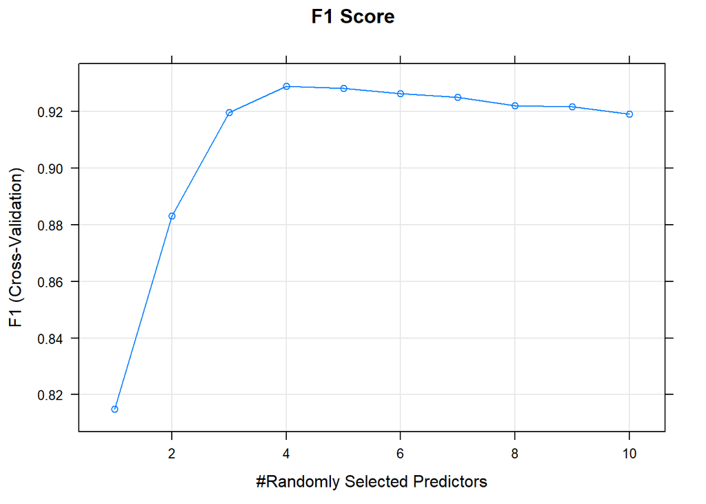

```r
# mtry tune plot
plot(rf, main="F1 Score", log="y")
```

```r
# Variables Importance
varImp(rf)
```

```
## rf variable importance
##
##                  Overall
## Age              100.000
## NumOfProducts     52.833
## Balance           49.233
## EstimatedSalary   48.585
## CreditScore       46.835
## Tenure            23.790
## IsActiveMember1    9.656
## GeographyGermany   6.171
## GenderMale         3.136
## HasCrCard1         1.410
## GeographySpain     0.000
```

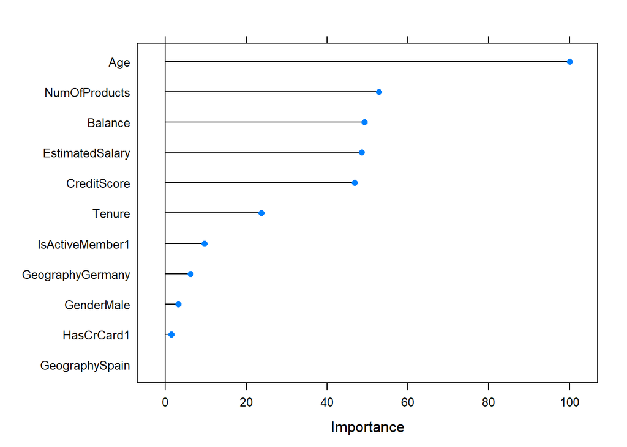

```r
plot(varImp(rf))
```

## SVM

```r
# Train SVM Radial
set.seed(1)

svm1<- caret::train(Exited ~ .,
                 data = train,
                 method = "svmRadial",
                 metric = "F1",
                 trControl = trainControl(method = "cv",
                          number = 10,
                          classProbs = TRUE,
                          summaryFunction = f1,
                          search = "grid"))
svm1
```

```
## Support Vector Machines with Radial Basis Function Kernel
##
## 12640 samples
##    10 predictor
##     2 classes: 'No', 'Yes'
##
## No pre-processing
## Resampling: Cross-Validated (10 fold)
## Summary of sample sizes: 11376, 11376, 11376, 11376, 11376, 11376, ...
## Resampling results across tuning parameters:
##
##   C     F1
##   0.25  0.8045617
##   0.50  0.8094587
##   1.00  0.8103212
##
## Tuning parameter 'sigma' was held constant at a value of 0.05696935
## F1 was used to select the optimal model using the largest value.
## The final values used for the model were sigma = 0.05696935 and C = 1.
```

```r
p4.1 <- predict(svm1, test)
cm4.1 <- confusionMatrix(p4.1, test$Exited, positive = "Yes")
cm4.1
```

```
## Confusion Matrix and Statistics
##
##           Reference
## Prediction   No  Yes
##        No  1358  124
##        Yes  285  301
##
##                Accuracy : 0.8022
##                  95% CI : (0.7844, 0.8192)
##     No Information Rate : 0.7945
##     P-Value [Acc > NIR] : 0.1999
##
##                   Kappa : 0.4689
##
##  Mcnemar's Test P-Value : 2.543e-15
##
##             Sensitivity : 0.7082
##             Specificity : 0.8265
##          Pos Pred Value : 0.5137
##          Neg Pred Value : 0.9163
##              Prevalence : 0.2055
##          Detection Rate : 0.1456
##    Detection Prevalence : 0.2834
##       Balanced Accuracy : 0.7674
##
##        'Positive' Class : Yes
##
```

```r
F1_4.1 <- F1_Score(y_pred = p4.1, y_true = test$Exited, positive = "Yes")
F1_4.1
```

```
## [1] 0.59545
```

```r
# Variables Importance
varImp(svm1)
```

```
## ROC curve variable importance
##
##                 Importance
## Age                100.000
## IsActiveMember      40.244
## NumOfProducts       34.657
## Balance             31.100
## Gender              28.271
## Geography           16.104
## CreditScore          6.994
## Tenure               2.777
## EstimatedSalary      2.432
## HasCrCard            0.000
```

```r
plot(varImp(svm1))
```

[output not shown]

```r
# Train SVM Linear
set.seed(1)

svm2<- caret::train(Exited ~ .,
                 data = train,
                 method = "svmLinear2",
                 metric = "F1",
                 trControl = trainControl(method = "cv",
                          number = 10,
                          classProbs = TRUE,
                          summaryFunction = f1,
                          search = "grid"))
svm2
```

```
## Support Vector Machines with Linear Kernel
##
## 12640 samples
##    10 predictor
##     2 classes: 'No', 'Yes'
##
## No pre-processing
## Resampling: Cross-Validated (10 fold)
## Summary of sample sizes: 11376, 11376, 11376, 11376, 11376, 11376, ...
## Resampling results across tuning parameters:
##
##   cost  F1
##   0.25  0.7259877
##   0.50  0.7263053
##   1.00  0.7263053
##
## F1 was used to select the optimal model using the largest value.
## The final value used for the model was cost = 0.5.
```

```r
p4.2 <- predict(svm2, test)
cm4.2 <- confusionMatrix(p4.2, test$Exited, positive = "Yes")
cm4.2
```

```
## Confusion Matrix and Statistics
##
##           Reference
## Prediction   No  Yes
##        No  1202  131
##        Yes  441  294
##
##                Accuracy : 0.7234
##                  95% CI : (0.7036, 0.7426)
##     No Information Rate : 0.7945
##     P-Value [Acc > NIR] : 1
##
##                   Kappa : 0.3333
##
##  Mcnemar's Test P-Value : <2e-16
##
##             Sensitivity : 0.6918
##             Specificity : 0.7316
##          Pos Pred Value : 0.4000
##          Neg Pred Value : 0.9017
##              Prevalence : 0.2055
##          Detection Rate : 0.1422
##    Detection Prevalence : 0.3554
##       Balanced Accuracy : 0.7117
##
##        'Positive' Class : Yes
##
```

```r
F1_4.2 <- F1_Score(y_pred = p4.2, y_true = test$Exited, positive = "Yes")
F1_4.2
```

```
## [1] 0.5068966
```

```r
# Variables Importance
varImp(svm2)
```

```
## ROC curve variable importance
##
##                 Importance
## Age                100.000
## IsActiveMember      40.244
## NumOfProducts       34.657
## Balance             31.100
## Gender              28.271
## Geography           16.104
## CreditScore          6.994
## Tenure               2.777
## EstimatedSalary      2.432
## HasCrCard            0.000
```

```r
plot(varImp(svm2))
```

[output not shown]

# Conclusions and Final Results

| Model | Accuracy | Precision | Recall | F1_Score |
| --- | --- | --- | --- | --- |
| Logistic Regression | 0.7510 | 0.4269 | 0.6188 | 0.5053 |
| KNN | 0.7727 | 0.4661 | 0.7271 | 0.5680 |
| Random Forest | 0.8486 | 0.6697 | 0.5200 | 0.5854 |
| SVM - Radial | 0.8022 | 0.5137 | 0.7082 | 0.5955 |
| SVM - Linear | 0.7234 | 0.4000 | 0.6918 | 0.5069 |

We can conclude that the best model is **SVM - Radial Kernel** with the highest F1 Score and the 2nd highest accuracy. The most relevant variable when predicting customer churn in this dataset is the customer’s age, while the least important one is whether or not the client has a credit card.

Accuracy, no doubt, is an important metric to consider but it does not always give the full picture. Instead, when using model-based metrics to evaluate a imbalanced classification problem, it is often times recommended to look at the precision and recall score to fully evaluate the overall effectiveness of a model. F1-score metric finds an equal balance between these two, which is extremely useful in scenarios when we are working with imbalanced datasets.

However, there is still room for performance improvement. I suggest trying other algorithms, such as ANN or XGBoost, and tuning parameters with other libraries and metrics that might lead to a better result.